# `sceptre` debugging part 3

Tim

2022-10-10

This is the third writeup in the `sceptre` debugging series. I ask and attempt to answer several questions.

1. To what extent does applying a more stringent QC threshold *actually* make the problem easier?

# Does applying more stringent QC actually make the problem easier?

In the previous writeup we saw that applying more stringent QC appears to improve the calibration of all methods across all datasets. However, using a more stringent QC threshold reduces the total number of pairs plotted, thereby preventing us from looking far out into the tail of the distribution. Thus, the apparent improvement in calibration might be a result of the reduction in the number of pairs plotted rather than an actual improvement in calibration.

We thefore seek to asses whether there is a true change in calibration that results from increasing the QC threshold (controlling for the number of pairs plotted). To this end, for each method, we create a QQ-plot that consists of two sets of pairs: (i) the *N* pairs that survive the QC threshold, and (ii) *N* pairsrandomly sampled (without replacement) from the full set of pairs. If these two sets of pairs differ in calibration quality — and in particular, if the former set of pairs exhibits better calibration than the latter — then we can conclude that QC actually does make the problem easier. Our QC threshold is an effective sample size of 250 cells or greater.

First, we plot the results for the Fisher exact test.

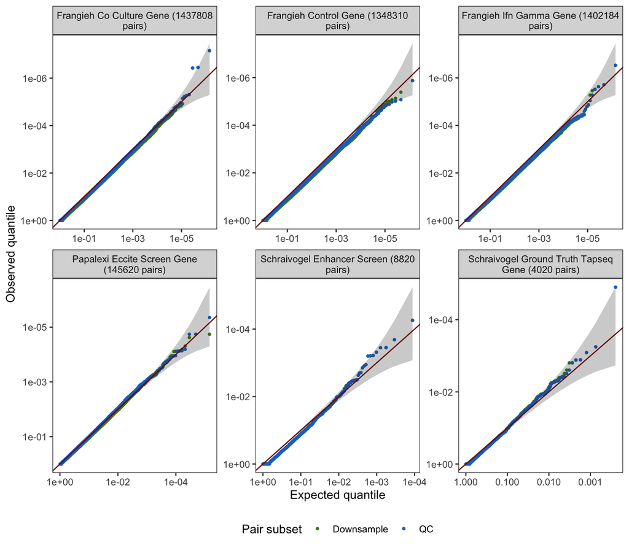

We do not observe a major difference between the QC’ed pairs and the randomly downsampled pairs in any of the plots. Next, we plot the results for Seurat DE.

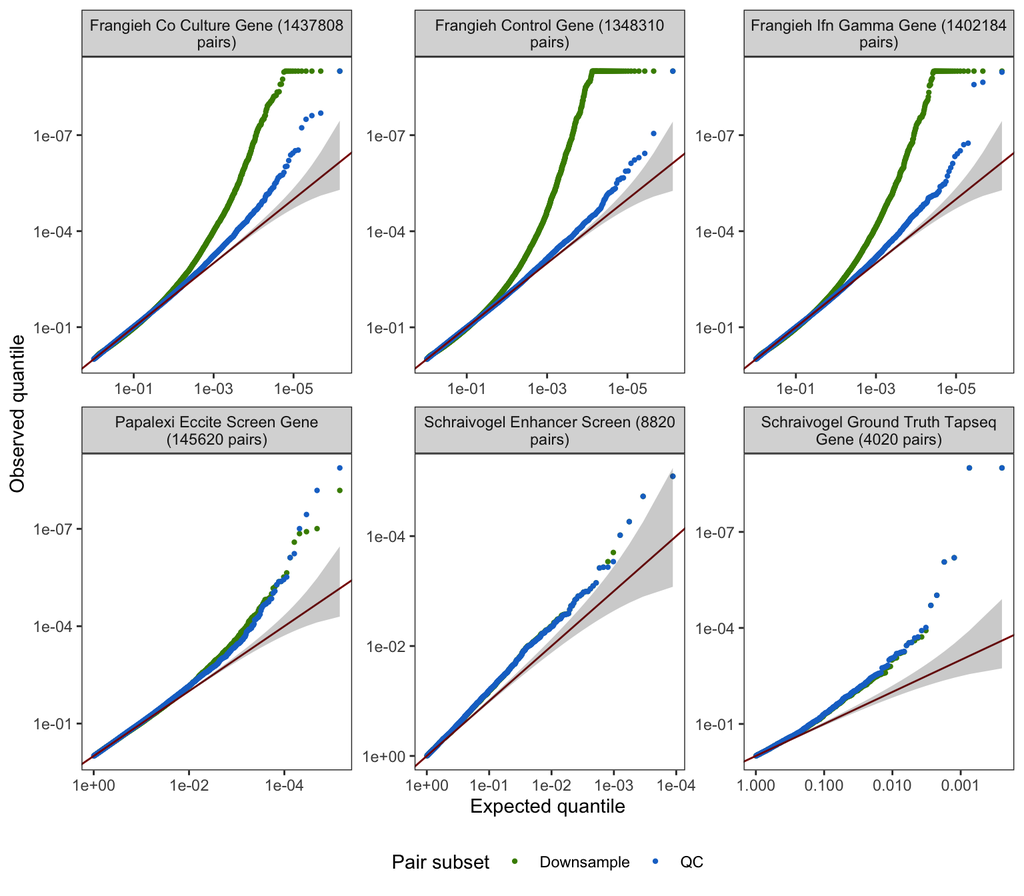

Finally, we plot the results for SCEPTRE.

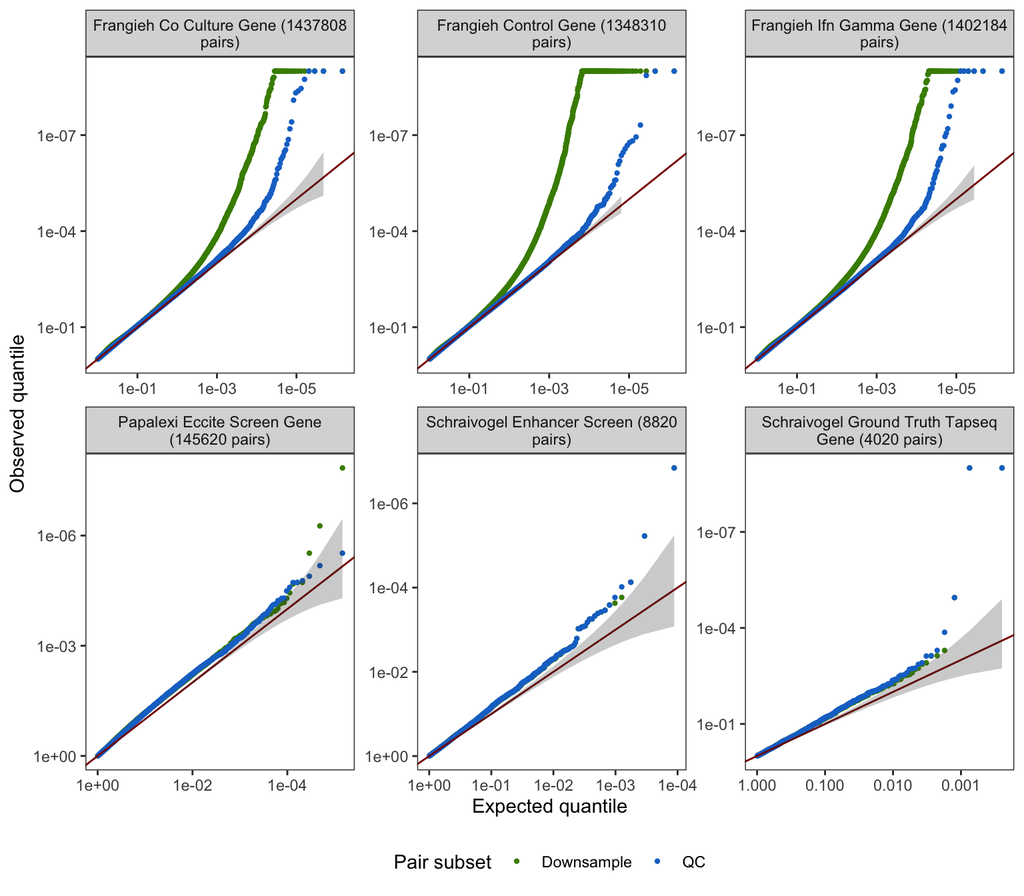